# Seat Clumping

Niel Schrage

2/12/2020

## Decision Making

do people clump by gender? how do you measure that? how to deal with grad students?

how would you measure a success case? compare against 50% / 50% compare sample v. reality to “idealized world” sufficient statistic for measurement clumping…

doing 1000 samples and then comparing the our sample mean against it 3/7 are clumped → is that a good representation 2/7 are equal → is that a good representation

### Visual Representation of the Class

M: 14, F: 16

MMFF

MMFF

MMFF

MMFF

MMFF

MMFF

MMFF

FF

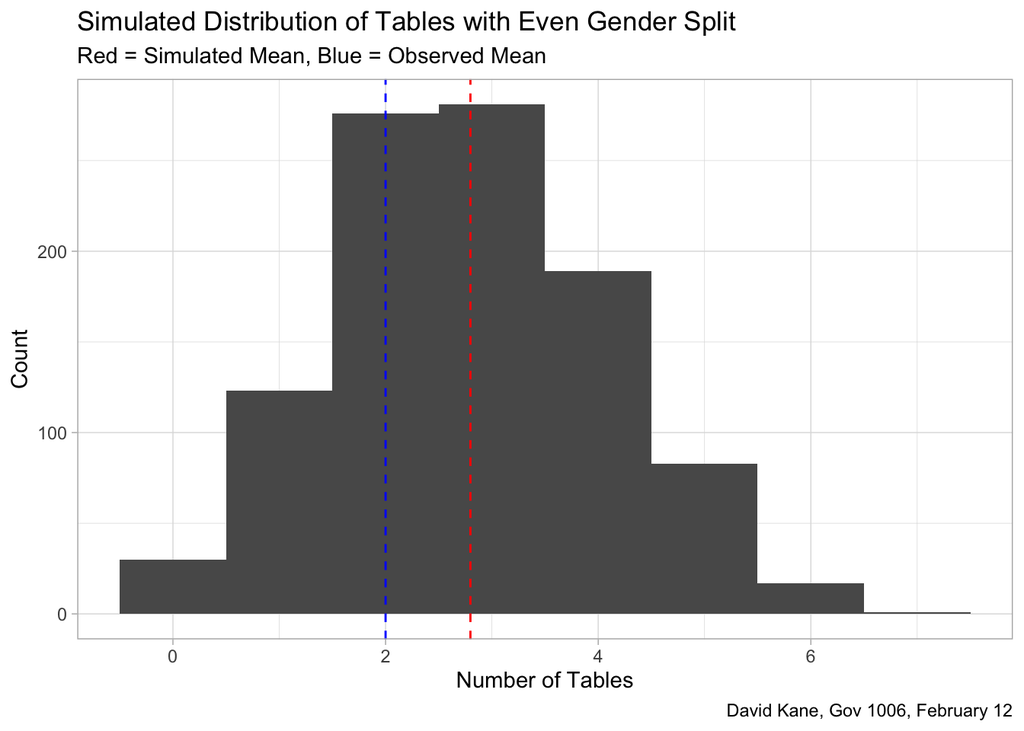

If we were to continue looking at this information, we would try to look at the tables that were completely male or female, because we know how many are even – but we don’t know about the others. Are they all female/all male or is there a 3-1 mix.